# Project 05: Communicate Data Findings

## Metro Bike Share - An Analysis of shared bike trips around Los Angeles from 2016 to 2020

#### (Data Source: https://bikeshare.metro.net/about/data/)

- **Student: Thomas Kallnik**
- **Date: April 8th, 2021**

During the project I gathered, assessed, cleaned and explored the metro bike share data set. This slideshow will illustrate the findings I made in the data as part of the explanatory analysis.

## The two data frames and their features:

(detailed descriptions of the features can be found on https://bikeshare.metro.net/about/data/)

### Trips data:

```python
display(df.sample(1))
print("\nTable Info:")
display(df.info())
```

| trip_id | duration | start_time | end_time | start_lat | start_lon | end_lat | end_lon | bike_id | plan_duration | trip_route_category | passholder_type | start_station | end_station | bike_type | year | month | day | weekday | distance | velocity | bike_symbol | weekend |
| --- | --- | --- | --- | --- | --- | --- | --- | --- | --- | --- | --- | --- | --- | --- | --- | --- | --- | --- | --- | --- | --- | --- |
| 112646134 | 6 | 2019-01-02 16:21:00 | 2019-01-02 16:27:00 | 34.05194 | -118.24353 | 34.05661 | -118.23721 | 6680 | 30.00000 | One Way | Monthly Pass | 3030.00000 | 3014.00000 | standard | 2019 | 1 | 2 | 2 | 0.77939 | 7.79390 | cross | 0 |

```
Table Info:
<class 'pandas.core.frame.DataFrame'>
Int64Index: 886400 entries, 1944075 to 151710184
Data columns (total 22 columns):
 #   Column               Non-Null Count   Dtype
---  ------               --------------   -----
 0   duration             886400 non-null  int64
 1   start_time           886400 non-null  datetime64[ns]
 2   end_time             886400 non-null  datetime64[ns]
 3   start_lat            886400 non-null  float64
 4   start_lon            886400 non-null  float64
 5   end_lat              886400 non-null  float64
 6   end_lon              886400 non-null  float64
 7   bike_id              886400 non-null  int64
 8   plan_duration        886231 non-null  float64
 9   trip_route_category  886400 non-null  category
 10  passholder_type      886400 non-null  category
 11  start_station        886400 non-null  float64
 12  end_station          886400 non-null  float64
 13  bike_type            886400 non-null  category
 14  year                 886400 non-null  int64
 15  month                886400 non-null  int64
 16  day                  886400 non-null  int64
 17  weekday              886400 non-null  int64
 18  distance             886400 non-null  float64
 19  velocity             886400 non-null  float64
 20  bike_symbol          886400 non-null  object
 21  weekend              886400 non-null  int64
dtypes: category(3), datetime64[ns](2), float64(9), int64(7), object(1)
memory usage: 137.8+ MB
```

```
None
```

### Stations data:

```python
display(df_stations.sample(3))
print("\nTable Info:")
display(df_stations.info())
```

| Station_ID | Station_Name | Go_live_date | Region | Status |
| --- | --- | --- | --- | --- |
| 4560 | Sepulveda & Charnock | 2020-12-28 | Westside | Active |
| 4315 | Union & 7th | 2019-02-06 | DTLA | Active |
| 4247 | 25th & Vermont | 2019-05-29 | DTLA | Active |

```
Table Info:
<class 'pandas.core.frame.DataFrame'>
Int64Index: 328 entries, 3000 to 4583
Data columns (total 4 columns):
 #   Column        Non-Null Count  Dtype
---  ------        --------------  -----
 0   Station_Name  328 non-null    object
 1   Go_live_date  328 non-null    datetime64[ns]
 2   Region        327 non-null    object
 3   Status        328 non-null    object
dtypes: datetime64[ns](1), object(3)
memory usage: 12.8+ KB
```

```
None
```

## In which areas of LA did the trips take place?

The blue border confines the area where trips in LA where recorded.

Red dots stand for the start of a bike trip, while yellow dots show trip ending locations. (Only a sample of 5000 trips is shown)

```python
# import gmplot package
df_map = df[["start_lat", "start_lon", "end_lat", "end_lon", "velocity", "distance", "duration"]].sample(5000)

lat_lim = [df_map.start_lat.min(), df_map.start_lat.max(), df_map.start_lat.max(), df_map.start_lat.min(), df_map.start_lat.min()]
lon_lim = [df_map.start_lon.min(), df_map.start_lon.min(), df_map.start_lon.max(), df_map.start_lon.max(), df_map.start_lon.min()]

gmap = gmplot.GoogleMapPlotter(34.05,
                                -118.25, 10)

# Draw border with min/max coordinates
gmap.plot(lat_lim, lon_lim,
           'cornflowerblue', edge_width = 2.5)

# scatterplot on google maps with starting locations
gmap.scatter(df_map.start_lat, df_map.start_lon,
                              color='red', size=100, marker=False)
gmap.scatter(df_map.end_lat, df_map.end_lon,
                              color='yellow', size=100, marker=False)

gmap.draw("map.html")

IFrame(src="map.html", width='100%', height='400')
```

[interactive chart not shown]

The majority of the trips took place in LA downtown, Santa Monica, Venice Beach, San Pedro, Universal Studios and Pasadena.

### Here are some of the longer trip routes across LA:

3 interesting statistics about the total amount of trips:

- Distance mean = 1.3 km, Duration mean = 17 min, Velocity mean = 7.3 km/h (if start and end were connected by a straight line)</font>

```python
df_map = df[["start_lat", "start_lon", "end_lat", "end_lon", "velocity", "distance", "duration"]].loc[df.duration > df.duration.quantile(q=.95)]

lat_lim = [df_map.start_lat.min(), df_map.start_lat.max(), df_map.start_lat.max(), df_map.start_lat.min(), df_map.start_lat.min()]
lon_lim = [df_map.start_lon.min(), df_map.start_lon.min(), df_map.start_lon.max(), df_map.start_lon.max(), df_map.start_lon.min()]

gmap3 = gmplot.GoogleMapPlotter(34.05,
                                -118.25, 10)

# Draw border with min/max coordinates
gmap3.plot(lat_lim, lon_lim,
           'cornflowerblue', edge_width = 2.5)

# draw random trip routes
for trip in random.sample(range(0, len(df_map)), 1000):
    latitude_list = [ df_map.iloc[trip].start_lat, df_map.iloc[trip].end_lat ]
    longitude_list = [ df_map.iloc[trip].start_lon, df_map.iloc[trip].end_lon ]
    gmap3.plot(latitude_list, longitude_list,
           'orange', edge_width = 2.5, edge_style="-")
    gmap3.scatter(latitude_list, longitude_list,
                              color='black', size=100, marker=False)

gmap3.draw("map3.html")

IFrame(src="map3.html", width='100%', height='400')
```

[interactive chart not shown]

Looks like some of the longest trips were even from the beach to Downtown or vice versa (~25km)!

### Now let's look at the amount of trips per month and their duration means over time:

The gap in 2020 must have been caused by the "Stay-At-Home-Order" issued on March 19th in California: https://www.ajmc.com/view/a-timeline-of-covid19-developments-in-2020

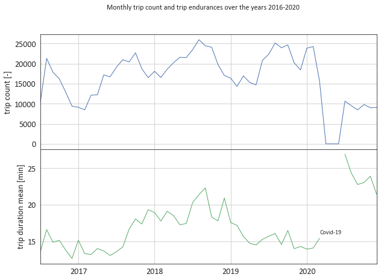

```python
df_month = df.groupby(pd.Grouper(key="start_time", freq='M'))["duration"].agg(["count", "mean"])
fig, axes = plt.subplots(2,1)
df_month.plot(subplots=True, ax=axes)
plt.subplots_adjust(hspace=0)
axes[0].set_ylabel("trip count [-]"); axes[0].legend("")
axes[1].set_ylabel("trip duration mean [min]"); plt.xlabel(""); axes[1].legend("")
plt.suptitle("Monthly trip count and trip endurances over the years 2016-2020");

plt.text(x="2020-03", y=16, s="Covid-19");
```

Probably the Metro Bike Share company just started their business in LA from 2016-2017. 2018 and 2019 seem comparable even though mean trip duration decreased and in 2020 obviously the pandemic hit the company. At the end of 2020 the remaining trips were probably not short trips to work but rather touristic trips after a long lockdown.

### Now let's look at the trip counts for each month of the year (2018 and 2019):

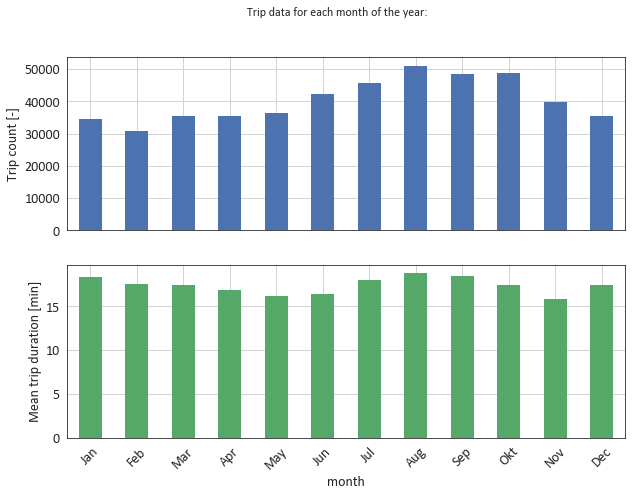

```python
axes = df.set_index(df.start_time, inplace=False).loc["2018":"2019"].groupby(["month"]).agg(["mean", "count"])[[("duration","count"), ("duration","mean")]].plot.bar(subplots=True, legend=False, title=["", ""]);
plt.suptitle("Trip data for each month of the year:");
axes[1].set_xticklabels(["Jan", "Feb", "Mar", "Apr", "May", "Jun", "Jul", "Aug", "Sep", "Okt", "Nov", "Dec"], rotation=45)
axes[0].set_ylabel("Trip count [-]")
axes[1].set_ylabel("Mean trip duration [min]");
```

As expected, especially in the warmer and months like july-october (also tourist period), there tend to be higher demands for bike sharing. On the other hand interestingly the mean trip duration in december and january are pretty high.

### Same Diagram only referring to weekdays (on the x-axis):

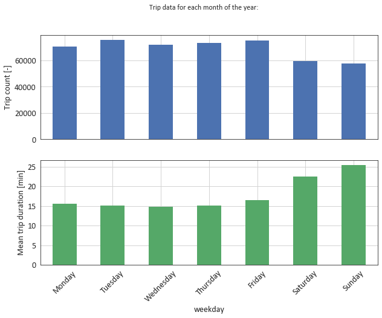

```python
axes = df.set_index(df.start_time, inplace=False).loc["2018":"2019"].groupby(["weekday"]).agg(["mean", "count"])[[("duration","count"), ("duration","mean")]].plot.bar(subplots=True, legend=False, title=["", ""]);
plt.suptitle("Trip data for each month of the year:");
axes[1].set_xticklabels(["Monday", "Tuesday", "Wednesday", "Thursday", "Friday", "Saturday", "Sunday"], rotation=45)
axes[0].set_ylabel("Trip count [-]")
axes[1].set_ylabel("Mean trip duration [min]");
```

Whilst the trip duration is usually higher on the weekend, the total trip count per weekday surprisingly shows clearly more bike rent traffic on working days (especially tuesday and friday). I assume a lot of people use the bike on working days for their short way to the job to escape the car traffic jams.

### Now let's check out the categorical features connected to duration:

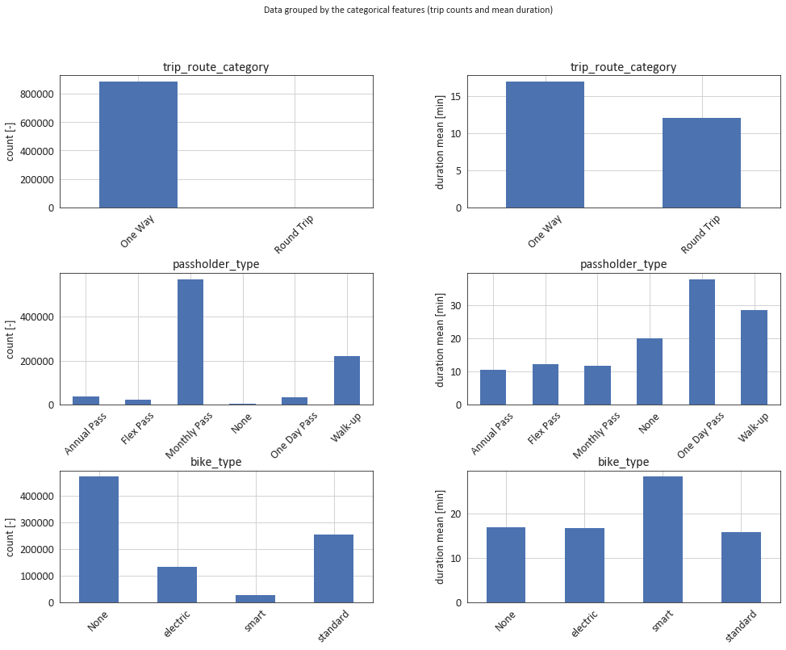

```python
fig, axes = plt.subplots(3, 2, figsize=(16,12))
for i, cat in enumerate(["trip_route_category", "passholder_type", "bike_type"]):
    df.groupby(cat).duration.count().plot.bar(ax=axes[i,0], title=cat, ylabel="count [-]", xlabel="")
    df.groupby(cat).duration.mean().plot.bar(ax=axes[i,1], title=cat, ylabel="duration mean [min]", xlabel="")
plt.subplots_adjust(wspace=.3, hspace=.5)
for ax in fig.axes:
    plt.sca(ax)
    plt.xticks(rotation=45)
plt.suptitle("Data grouped by the categorical features (trip counts and mean duration)");
```

The same graphs for distance instead of duration almost look respectively the same with one exception:

- Annual passholders seem to ride longer distances compared to flex and monthly passes even though they spend less time on the bike.
- As conclusion the annual passholders must have higher speeds which the following graph illustrates.
  - Consider that the mean velocity is a fictitious feature calculated from the direct connection of start and end location and is hence biased by travel pauses as well as actual routes/directions.

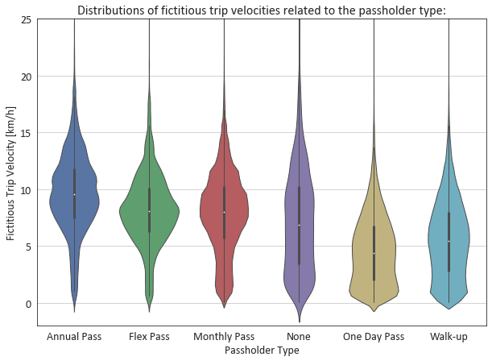

```python
sn.violinplot(x=df.passholder_type, y=df.velocity); plt.ylim(-2,25);
plt.title("Distributions of fictitious trip velocities related to the passholder type:")
plt.ylabel("Fictitious Trip Velocity [km/h]"); plt.xlabel("Passholder Type");
```

### The following plots will show dependencies between starting locations and trip velocities, passholder types and bike types.

```python
from plotly.offline import download_plotlyjs, init_notebook_mode, plot, iplot
init_notebook_mode(connected=True)
df_3d = df.drop(df.loc[(df.duration<2) | (df.duration>60)].index).sample(frac=.01)

trace1 = go.Scatter3d(
    x=df_3d.start_lon,
    y=df_3d.start_lat,
    z=df_3d.passholder_type,
    marker=dict(
        color=df_3d.duration,
        size=2,
        sizemode='diameter',
        showscale=True,
        colorbar=dict(title='Trip duration [min]'),
    ),
    mode='markers',
)

layout = go.Layout (
        scene = dict(
            xaxis = dict (title = "Start Latitude"),
            yaxis = dict (title = "Start Longitude"),
            zaxis = dict (title = "Passholder Type"),
        ),
        title = "4D Scatterplot"
    )

fig = go.Figure(data=[trace1], layout = layout)
iplot(fig)
```

[interactive chart not shown]

The plot shows, that the longest trips in terms of time appear to happen mostly around Downtown or Santa Monica from Walk-Up or One Day Passholders. There are no trips from Annual Passholders recorded in Pasadena nore from Flex Passholders at the Oceanside.

```python
df_3d = df.drop(df.loc[(df.duration<2) | (df.duration>60)].index).sample(frac=.01)

trace1 = go.Scatter3d(
    x=df_3d.start_lon,
    y=df_3d.start_lat,
    z=df_3d.bike_type,
    marker=dict(
        color=df_3d.velocity,
        size=2,
        sizemode='diameter',
        showscale=True,
        colorbar=dict(title='Trip velocity [km/h]'),
    ),
    mode='markers',
)

layout = go.Layout (
        scene = dict(
            xaxis = dict (title = "Start Latitude"),
            yaxis = dict (title = "Start Longitude"),
            zaxis = dict (title = "Bike Type"),
        ),
        title = "4D Scatterplot"
    )

fig = go.Figure(data=[trace1], layout = layout)
iplot(fig)
```

[interactive chart not shown]

The speeds are well distributed even though the highest ones seem to be located in Downtown and Santa Monica. Smart Bikes can almost only be found at the Coast or near Universal Studios and all trips started in Pasadena have no recorded bike_category.

```python
df_scatter = df.sample(frac=0.02)
fig = px.scatter(df_scatter, x="start_lon", y="start_lat", color="weekend", title="Trips starting locations subdivided by workingdays (weekend=0) and weekend (weekend=1):")
fig.show();
```

[interactive chart not shown]

Apparently there is no area specifically used "only" on weekends.

## Questions for the reviewer

1. In my slideshow I tried to pack text/markdowns and plots under each other with slide-type "fragment". Sometimes text or plots were cut and i couldn't scroll to see the following element (e.g. Categorical subplot slide). In addition to that the text or plots as fragment were not centered under the "sub-slide" part. How can i fix those problems? I really have a hard time formatting my slides so that I can always have a Title with a comment, then a figure and afterwards a comment on the figure (all that on one slide). Can you recommend me any kind of documentation on that topic?
- The line of code that i use to convert to slides is the following:
  - jupyter nbconvert 05_udacity_projects/05_Communicate_Data_Findings/20210407_Kallnik_Project_05_Explanatory_Part.ipynb --to slides --template output-toggle.tpl --SlidesExporter.reveal_scroll=True